# Preliminary Analysis

### Yield saved from fungicide applications

The data plotted below are from the past field trials (2011 - 2017) described in the aforementioned table. All data are a list of mean values from each treatment applied in each experiment. Various factors have been studied in the previous experiments which may influence the following results. The following variables were disregarded in the plots below.

1. Fungicide type
2. Fungicide dose
3. row spacing
4. Host cultivars (probably is a covariate with season due to changing cultivars over time)
5. Experiment location
6. Final disease rating

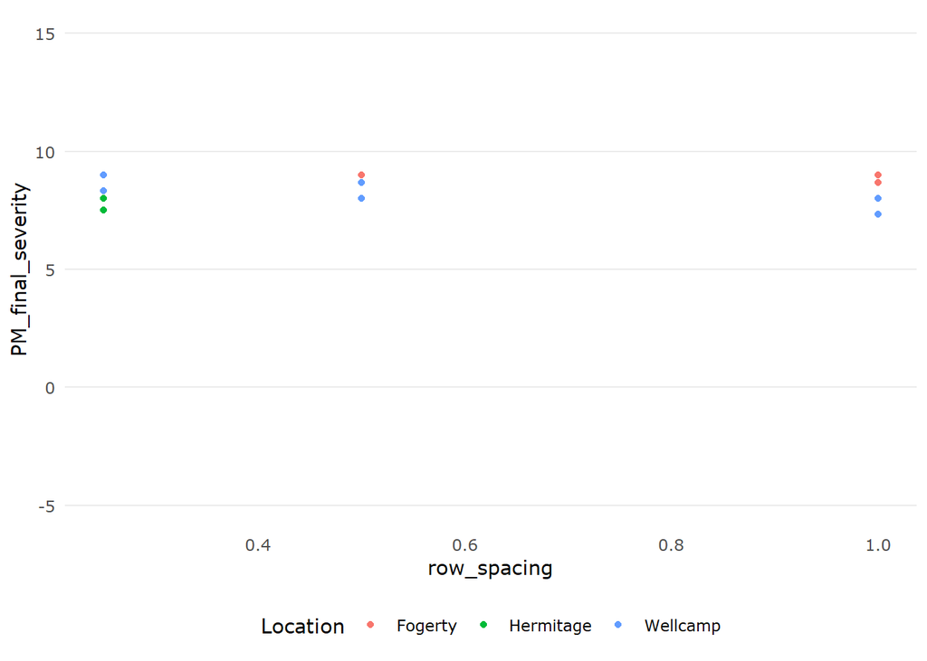

```r
# Which row spacing leads to the higher disease severity
PM_MB_means %>%
   filter(Year >= 2017)%>%
   filter(Fungicide == "control") %>%
ggplot(aes(y = PM_final_severity, x = row_spacing, colour = Location))+
   geom_point()+
 #  geom_smooth()+
   scale_y_continuous(limits = c(-5,15))+
   theme_usq()
```

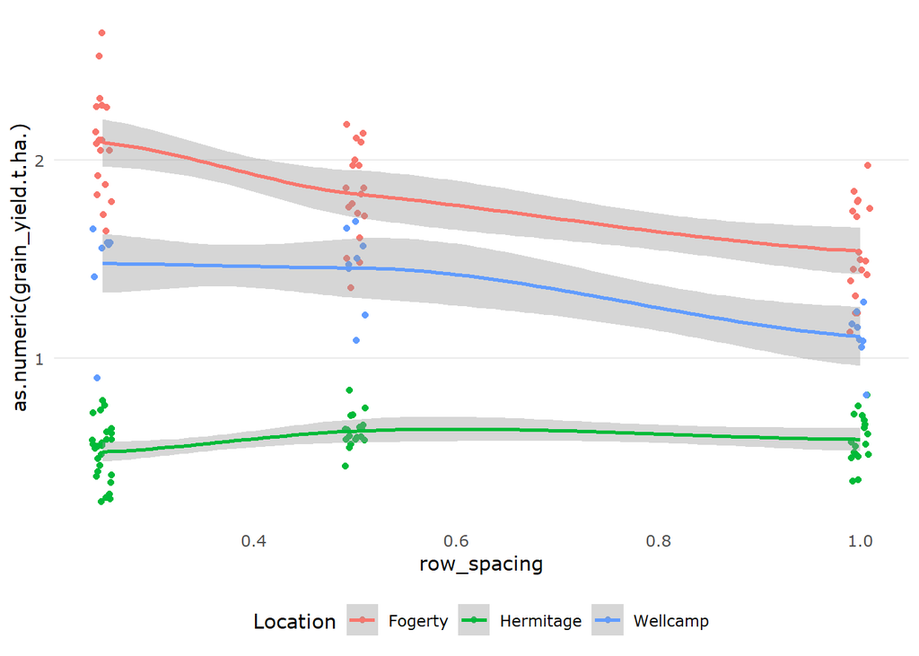

```r
# Which row spacing leads to the higher yeild potential
PM_MB_means %>%
   filter(Year >= 2017)%>%
#   filter(Fungicide == "control") %>%
ggplot(aes(y = as.numeric(grain_yield.t.ha.), x = row_spacing, colour = Location))+
   geom_jitter(width = 0.01)+
   geom_smooth()+
#   scale_y_continuous(limits = c(-5,15))+
   theme_usq()
```

#### Effect of Fungicide

**on proportional yield gain with repect to time of application** First lets look at the quantiles for each fungicide irrespective of other factors. We will focus on proportional yield gain, compared to no treatment control, as this should partially correct for some spatial and seasonal effects.

```r
PM_MB_means %>%
   group_by(Fungicide) %>%
   summarise(n = length(prop_YG),
             lower_2.5 = quantile(prop_YG, na.rm = T, c(0.025)),
             median = median(prop_YG, na.rm = T),
             mean = mean(prop_YG, na.rm = T),
             upper_97.5 = quantile(prop_YG, na.rm = T, c(0.975))) %>%
   filter(n >= 5) %>% # remove any fungicide groups with less than 5 observations
   arrange(desc(median)) %>%
   kable(caption = "Fungicide effect on proportion of yield gain") %>%
   kable_styling(fixed_thead = T, full_width = T)
```

Fungicide effect on proportion of yield gain

| Fungicide | n | lower_2.5 | median | mean | upper_97.5 |
| --- | --- | --- | --- | --- | --- |
| 200 g/l Tebuconazole + 120 g/l Azoxystrobin | 36 | -0.2319072 | 0.1733261 | 0.1673186 | 0.4290451 |
| propiconazole | 56 | -0.2153039 | 0.1332566 | 0.1510316 | 0.5684428 |
| Tebeconazole | 77 | -0.1822948 | 0.0963855 | 0.1136060 | 0.4679573 |
| 200g/L azoxystrobin + 80 g/L cyproconazole | 27 | -0.1000144 | 0.0634921 | 0.1561990 | 0.6091212 |
| Sulphur | 74 | -0.1746775 | 0.0328737 | 0.0703582 | 0.5290957 |
| Carbendazim | 15 | -0.1652929 | 0.0183346 | 0.0516008 | 0.3331778 |
| Pyraclostrobin | 8 | -0.1038760 | 0.0140763 | 0.0198351 | 0.1387547 |
| Amistar | 6 | -0.1321620 | 0.0076268 | 0.0142136 | 0.1488095 |
| control | 54 | NA | NA | NaN | NA |

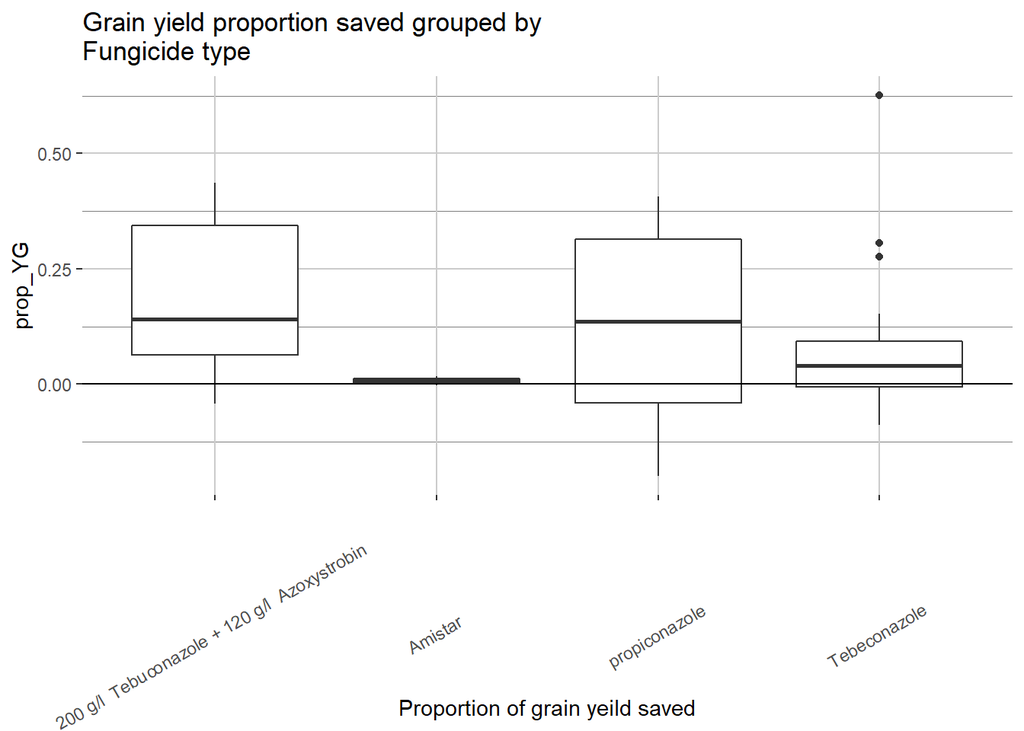

```r
# plot table as a box plot
PM_MB_means %>%
   filter(Fungicide == c("200 g/l  Tebuconazole + 120 g/l  Azoxystrobin" , "Amistar","Tebeconazole","propiconazole"))%>%
ggplot(aes(y = prop_YG, x = Fungicide))+
   geom_boxplot()+
   geom_hline(aes(yintercept = 0), size =0.5)+
   #scale_fill_discrete(labels = c("15-7 days before","same day","one day after","8-9 days after","13-19 days after"))+
   labs(x = "Proportion of grain yeild saved",
   title = "Grain yield proportion saved grouped by\nFungicide type")+
   theme(panel.grid.major = element_line(colour = "grey80"),
         panel.grid.minor = element_line(colour = "grey50"),
         panel.background = element_rect(fill = NA))+
   guides(fill=guide_legend(title="Fungicide"))+
   coord_cartesian()+
   theme(axis.text.x = element_text(angle = 30, hjust =.51, vjust = 0.3))
```

```r
   #scale_x_continuous(limits = c(-0.3,0.6))
```

There was some hope groups of fungicide could be combined, ie Propiconazole and Tebeconazole, however it seems that they have different efficacies. Let us look to see if there is anything skewing the above.

```r
PM_MB_means %>%
   group_by(Fungicide, total_Fungicide) %>%
   summarise(n = length(prop_YG),
             lower_2.5 = quantile(prop_YG, na.rm = T, c(0.025)),
             median = median(prop_YG, na.rm = T),
             mean = mean(prop_YG, na.rm = T),
             upper_97.5 = quantile(prop_YG, na.rm = T, c(0.975))) %>%
   filter(n >= 5) %>% # remove any fungicide groups with less than 5 observations
   arrange(desc(median)) %>%
   kable(caption = "Fungicide effect on proportion of yield gain") %>%
   kable_styling(fixed_thead = T, full_width = T)
```

Fungicide effect on proportion of yield gain

| Fungicide | total_Fungicide | n | lower_2.5 | median | mean | upper_97.5 |
| --- | --- | --- | --- | --- | --- | --- |
| 200 g/l Tebuconazole + 120 g/l Azoxystrobin | 2 | 18 | -0.2378990 | 0.1885871 | 0.1737051 | 0.4233369 |
| Sulphur | 2 | 34 | -0.0954537 | 0.1676904 | 0.1796112 | 0.5922184 |
| propiconazole | 2 | 27 | -0.1392081 | 0.1515603 | 0.1772404 | 0.6560586 |
| propiconazole | 1 | 26 | -0.2084727 | 0.1335656 | 0.1482543 | 0.4611436 |
| 200 g/l Tebuconazole + 120 g/l Azoxystrobin | 1 | 18 | -0.1105724 | 0.1297686 | 0.1609322 | 0.4107565 |
| Tebeconazole | 3 | 5 | -0.1695088 | 0.1061125 | 0.0871678 | 0.2650898 |
| Tebeconazole | 1 | 36 | -0.1307250 | 0.1035850 | 0.1174632 | 0.4733056 |
| 200g/L azoxystrobin + 80 g/L cyproconazole | 2 | 9 | -0.1236481 | 0.0843373 | 0.1987469 | 0.5677763 |
| Tebeconazole | 2 | 36 | -0.1082282 | 0.0722911 | 0.1134209 | 0.4694340 |
| 200g/L azoxystrobin + 80 g/L cyproconazole | 1 | 14 | -0.0236934 | 0.0623583 | 0.1596658 | 0.6182091 |
| Sulphur | 3 | 7 | -0.1767008 | 0.0509326 | 0.0013596 | 0.1417168 |
| Carbendazim | 2 | 5 | -0.1819353 | 0.0183346 | 0.0368333 | 0.1876341 |
| Carbendazim | 1 | 10 | -0.0907066 | 0.0170173 | 0.0589845 | 0.3545154 |
| Sulphur | 1 | 30 | -0.1619475 | 0.0061759 | 0.0394532 | 0.3768918 |
| control | 0 | 52 | NA | NA | NaN | NA |

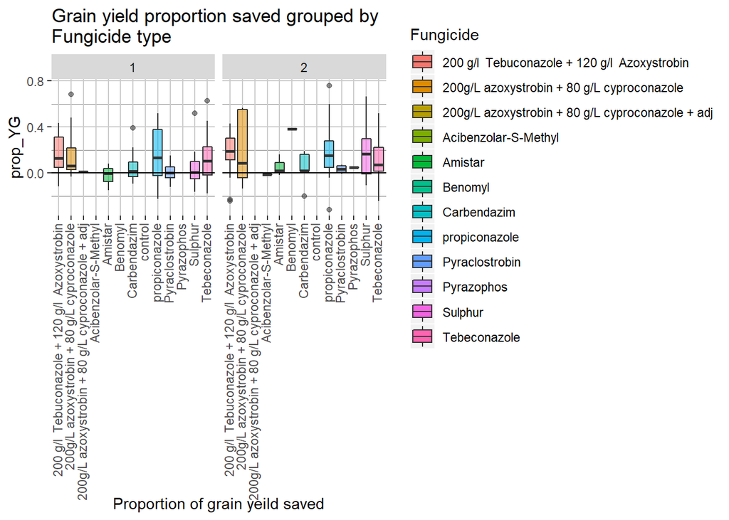

```r
PM_MB_means %>%
   filter(total_Fungicide ==1 |total_Fungicide ==2 ) %>%
ggplot(aes(y = prop_YG, x = Fungicide))+
   facet_grid(cols = vars(total_Fungicide))+
   geom_boxplot(aes(fill = Fungicide, alpha = 0.5))+
   geom_hline(aes(yintercept = 0), size =0.5)+
   #scale_fill_discrete(labels = c("15-7 days before","same day","one day after","8-9 days after","13-19 days after"))+
   labs(x = "Proportion of grain yeild saved",
   title = "Grain yield proportion saved grouped by\nFungicide type")+
   theme(panel.grid.major = element_line(colour = "grey80"),
         panel.grid.minor = element_line(colour = "grey50"),
         panel.background = element_rect(fill = NA))+
   guides(fill=guide_legend(title="Fungicide"))+
   coord_cartesian()+
   theme(axis.text.x = element_text(angle = 90, hjust = 1, vjust = 0.3))
```

```r
   #scale_x_continuous(limits = c(-0.3,0.6))
```

Lets run this by a quick linear mixed effect model

```r
levels(PM_MB_means$Fungicide)
```

```
##  [1] "200 g/l  Tebuconazole + 120 g/l  Azoxystrobin"
##  [2] "200g/L azoxystrobin + 80 g/L cyproconazole"
##  [3] "200g/L azoxystrobin + 80 g/L cyproconazole + adj"
##  [4] "Acibenzolar-S-Methyl"
##  [5] "Amistar"
##  [6] "Benomyl"
##  [7] "Carbendazim"
##  [8] "control"
##  [9] "propiconazole"
## [10] "Pyraclostrobin"
## [11] "Pyrazophos"
## [12] "Sulphur"
## [13] "Sulphur (SC)"
## [14] "Sulphur (Ultra SC)"
## [15] "Sulphur (WP)"
## [16] "Tebeconazole"
```

```r
PM_MB_means$Fungicide <- factor(PM_MB_means$Fungicide, levels = c("control","propiconazole","Tebeconazole",
                                                        "Amistar",
                                                        "200 g/l  Tebuconazole + 120 g/l  Azoxystrobin", "Carbendazim",
                                                        "Benomyl",
                                                         "Pyrazophos","Acibenzolar-S-Methyl",
                                                        "Sulphur", "Sulphur (SC)","Sulphur (Ultra SC)","Sulphur (WP)"
                                                        ))

PM_MB_lmer.1 <- lmer(prop_YG ~ Fungicide * as.factor(total_Fungicide) + row_spacing + (1|Trial_ref),
     data = subset(PM_MB_means, total_Fungicide == 1 | total_Fungicide == 2))
```

```
## fixed-effect model matrix is rank deficient so dropping 3 columns / coefficients
```

```r
summary(PM_MB_lmer.1)
```

```
## Linear mixed model fit by REML ['lmerMod']
## Formula: prop_YG ~ Fungicide * as.factor(total_Fungicide) + row_spacing +
##     (1 | Trial_ref)
##    Data: subset(PM_MB_means, total_Fungicide == 1 | total_Fungicide ==
##     2)
##
## REML criterion at convergence: -89.1
##
## Scaled residuals:
##      Min       1Q   Median       3Q      Max
## -2.84315 -0.59342 -0.04762  0.52633  3.11538
##
## Random effects:
##  Groups    Name        Variance Std.Dev.
##  Trial_ref (Intercept) 0.008735 0.09346
##  Residual              0.027808 0.16676
## Number of obs: 207, groups:  Trial_ref, 21
##
## Fixed effects:
##                                                                                    Estimate
## (Intercept)                                                                         0.06784
## FungicideTebeconazole                                                              -0.01474
## FungicideAmistar                                                                   -0.13160
## Fungicide200 g/l  Tebuconazole + 120 g/l  Azoxystrobin                              0.02625
## FungicideCarbendazim                                                               -0.03405
## FungicideBenomyl                                                                    0.14455
## FungicidePyrazophos                                                                -0.18944
## FungicideAcibenzolar-S-Methyl                                                      -0.25466
## FungicideSulphur                                                                   -0.09500
## as.factor(total_Fungicide)2                                                         0.02642
## row_spacing                                                                         0.10829
## FungicideTebeconazole:as.factor(total_Fungicide)2                                  -0.03782
## FungicideAmistar:as.factor(total_Fungicide)2                                        0.07743
## Fungicide200 g/l  Tebuconazole + 120 g/l  Azoxystrobin:as.factor(total_Fungicide)2 -0.01951
## FungicideCarbendazim:as.factor(total_Fungicide)2                                   -0.06049
## FungicideSulphur:as.factor(total_Fungicide)2                                        0.07372
##                                                                                    Std. Error
## (Intercept)                                                                           0.05273
## FungicideTebeconazole                                                                 0.04538
## FungicideAmistar                                                                      0.13086
```

[output cut: 15 more lines]

```
## FungicideTebeconazole                                                               -0.325
## FungicideAmistar                                                                    -1.006
## Fungicide200 g/l  Tebuconazole + 120 g/l  Azoxystrobin                               0.500
## FungicideCarbendazim                                                                -0.451
## FungicideBenomyl                                                                     0.780
## FungicidePyrazophos                                                                 -1.022
## FungicideAcibenzolar-S-Methyl                                                       -1.374
## FungicideSulphur                                                                    -1.505
## as.factor(total_Fungicide)2                                                          0.552
## row_spacing                                                                          2.325
## FungicideTebeconazole:as.factor(total_Fungicide)2                                   -0.616
## FungicideAmistar:as.factor(total_Fungicide)2                                         0.446
## Fungicide200 g/l  Tebuconazole + 120 g/l  Azoxystrobin:as.factor(total_Fungicide)2  -0.268
## FungicideCarbendazim:as.factor(total_Fungicide)2                                    -0.519
## FungicideSulphur:as.factor(total_Fungicide)2                                         0.855
```

```
##
## Correlation matrix not shown by default, as p = 16 > 12.
## Use print(x, correlation=TRUE)  or
##     vcov(x)        if you need it
```

```
## fit warnings:
## fixed-effect model matrix is rank deficient so dropping 3 columns / coefficients
```

How many trials contain all of the most studied fungicides

```r
Tebe_trials <- unique(PM_MB_means[PM_MB_means$Fungicide == "Tebeconazole",]$Trial_ref)
Propi_trials <- unique(PM_MB_means[PM_MB_means$Fungicide == "propiconazole",]$Trial_ref)
Amistar_trials <- unique(PM_MB_means[PM_MB_means$Fungicide == "Amistar",]$Trial_ref)

intersect(
   intersect(Tebe_trials,Propi_trials)
   ,Amistar_trials)
```

```
## [1] NA
```

```
## [1]   0 -28 -20 -14   1   8
```

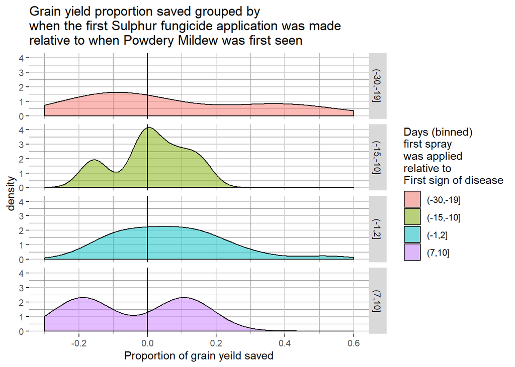

This plot shows that there is not a good probability that Sulphur will help save yield, even when it is sprayed at the ideal time.

```r
Chemical <- c("Amistar","Carbendazim","Tebeconazole", "propiconazole")
levels(factor(PM_MB_means$Fungicide))
```

```
##  [1] "control"
##  [2] "propiconazole"
##  [3] "Tebeconazole"
##  [4] "Amistar"
##  [5] "200 g/l  Tebuconazole + 120 g/l  Azoxystrobin"
##  [6] "Carbendazim"
##  [7] "Benomyl"
##  [8] "Pyrazophos"
##  [9] "Acibenzolar-S-Methyl"
## [10] "Sulphur"
```

```
## Amistar
```

```
## [1] -17  -5   5  10
```

```
## Carbendazim
```

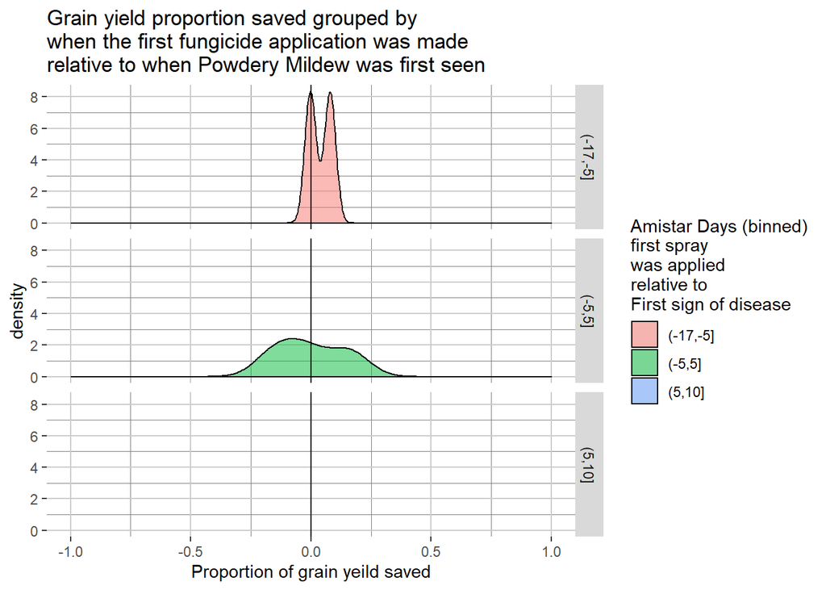

```
## [1] -17  -5   5  10
```

```
## Tebeconazole
```

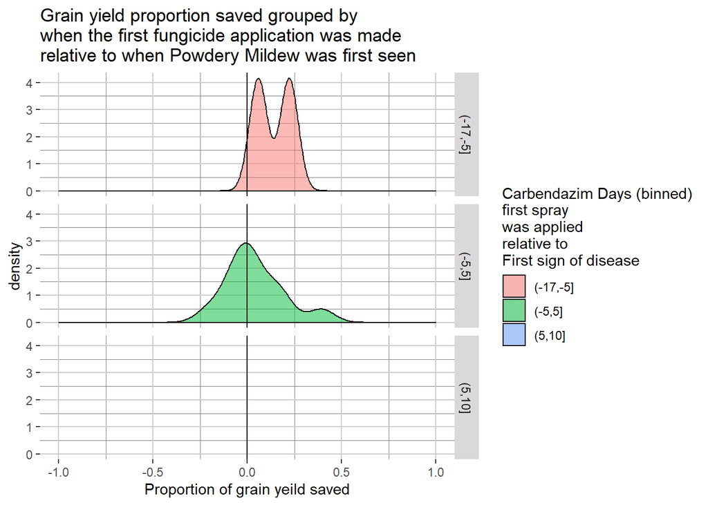

```
## [1] -363   -5    5   20
```

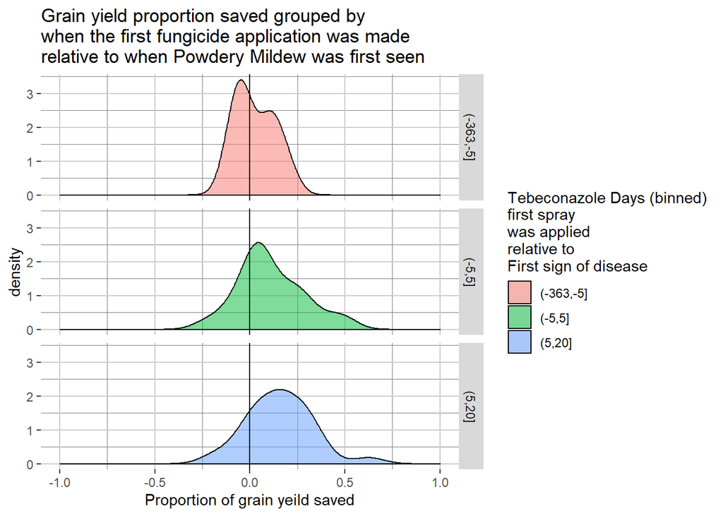

```
## propiconazole[1] -17  -5   5  13
```

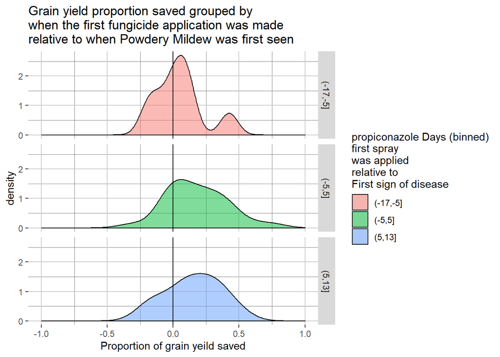

```r
# Generates multiple plots for each type of fungicide tested
for(Chem in Chemical){
PM_MB_means2 <- PM_MB_means1 %>%
   filter(Fungicide == Chem)

cat(Chem)

# the following code 'spray_group' sets the spray_diff groupings that are used in the plots
spray_group <- c(min(unique(PM_MB_means2$spray_diff))-1,
      -5, 5,
      max(unique(PM_MB_means2$spray_diff))+1)

spray_group < - c(sort(unique(PM_MB_means2$spray_diff)-1), max(unique(PM_MB_means2$spray_diff)))

print(spray_group)

p1 <- ggplot(PM_MB_means2, aes(prop_YG))+
   geom_density(aes(fill = cut(PM_MB_means2$spray_diff, spray_group)), alpha = 0.5)+
   geom_vline(aes(xintercept = 0), size =0.5)+
   facet_grid(cut(PM_MB_means2$spray_diff, spray_group)~.)+
   #scale_fill_discrete(labels = c("15-7 days before","same day","one day after","8-9 days after","13-19 days after"))+
   labs(x = "Proportion of grain yeild saved",
   title = "Grain yield proportion saved grouped by\nwhen the first fungicide application was made\nrelative to when Powdery Mildew was first seen")+
   theme(panel.grid.major = element_line(colour = "grey80"),
         panel.grid.minor = element_line(colour = "grey50"),
         panel.background = element_rect(fill = NA))+
   guides(fill=guide_legend(title=paste(Chem,"Days (binned)\nfirst spray \nwas applied\nrelative to\nFirst sign of disease")))+
   scale_x_continuous(limits = c(-1,1))

print(p1)

}
```

It seems the calculation of spray diff does not elucidate any differences between application dates.

### Yield saved

**Number of fungicide applications** The following density plots show mean yield saved in relation to how many sprays were applied.

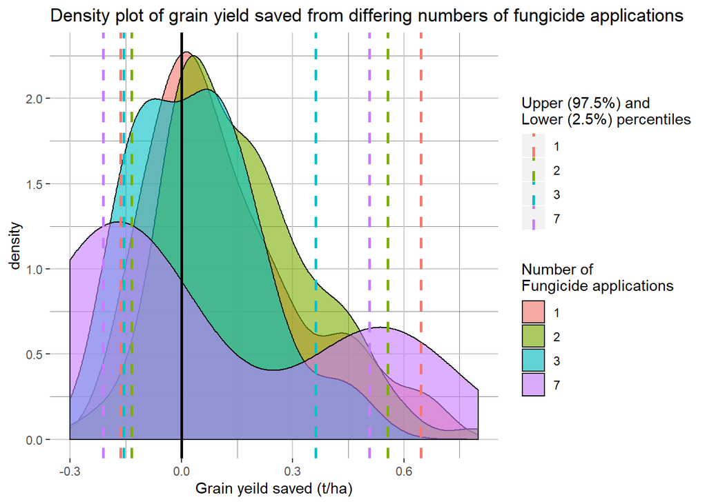

Yeild gain for each number of fungicide applications

| total_Fungicide | n | lower_2.5 | median | mean | upper_97.5 |
| --- | --- | --- | --- | --- | --- |
| 1 | 123 | -0.1643374 | 0.0760966 | 0.1238669 | 0.6460759 |
| 2 | 126 | -0.1338754 | 0.1280000 | 0.1562037 | 0.5564983 |
| 3 | 15 | -0.1554185 | 0.0651200 | 0.0434163 | 0.3616750 |
| 7 | 3 | -0.2117350 | -0.1269000 | 0.0655667 | 0.5064650 |

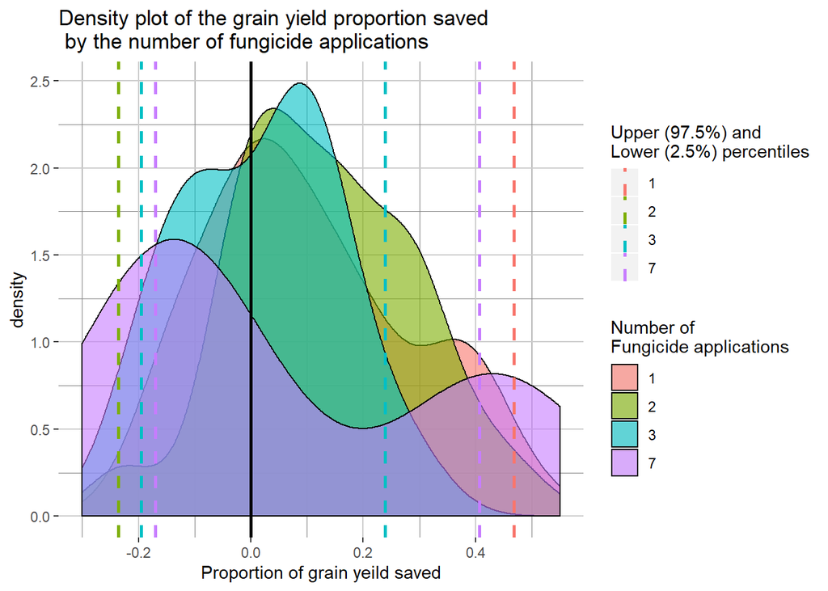

Proportion of yeild gain for each number of fungicide applications

| total_Fungicide | lower_2.5 | median | mean | upper_97.5 |
| --- | --- | --- | --- | --- |
| 1 | -0.1700960 | 0.0807453 | 0.1099887 | 0.4678434 |
| 2 | -0.2360948 | 0.1372313 | 0.1426393 | 0.5582074 |
| 3 | -0.1946478 | 0.0509326 | 0.0175347 | 0.2386507 |
| 7 | -0.1698909 | -0.1018214 | 0.0526091 | 0.4063749 |

#### Timing of Fungicide application

The following density plots show mean yield saved (t/Ha) or proportion yield saved in relation to when the first fungicide spray was applied in relation to when powdery mildew was first seen in the mungbean crop.

```r
# What range of
unique(PM_MB_means1$days_from_1st)
```

```
##  [1]    0  -40  -27  -14  -28    1  -13  -10  -16    3    8   19    9   13
## [15]   12  -11    7 -362 -354
```

```r
PM_MB_means1 %>%
   group_by(cut(PM_MB_means1$days_from_1st, c(-41,-20,-15,-12,-0.5,1.5,7,10,12,20))) %>%
   summarise(n = length(prop_YG),
             lower_2.5 = quantile(prop_YG, na.rm = T, c(0.025)),
             median = median(prop_YG, na.rm = T),
             mean = mean(prop_YG, na.rm = T),
             upper_97.5 = quantile(prop_YG, na.rm = T, c(0.975))) %>%
   kable(caption = "Difference in days between first sign of disease and first fungicide application and the effect on proportion of yield gain") %>%
   kable_styling(fixed_thead = T, full_width = T)
```

Difference in days between first sign of disease and first fungicide application and the effect on proportion of yield gain

| cut(…) | n | lower_2.5 | median | mean | upper_97.5 |
| --- | --- | --- | --- | --- | --- |
| (-41,-20] | 20 | -0.1609344 | 0.0173736 | 0.0777757 | 0.4166232 |
| (-20,-15] | 7 | 0.0291005 | 0.0846561 | 0.1186697 | 0.2174603 |
| (-15,-12] | 20 | -0.1936631 | 0.0258250 | 0.0046358 | 0.1415967 |
| (-12,-0.5] | 16 | -0.1673893 | 0.0175594 | 0.0585435 | 0.3998296 |
| (-0.5,1.5] | 119 | -0.1418839 | 0.1018651 | 0.1321300 | 0.5707854 |
| (1.5,7] | 41 | -0.2425627 | 0.1391693 | 0.1211587 | 0.4710179 |
| (7,10] | 6 | 0.0418093 | 0.2506337 | 0.1993076 | 0.3016477 |
| (10,12] | 27 | -0.1775688 | 0.1931628 | 0.2107359 | 0.5554968 |
| (12,20] | 5 | -0.0216624 | 0.1076524 | 0.0759759 | 0.1639429 |
| NA | 6 | -0.0714381 | -0.0336485 | -0.0148254 | 0.0701547 |

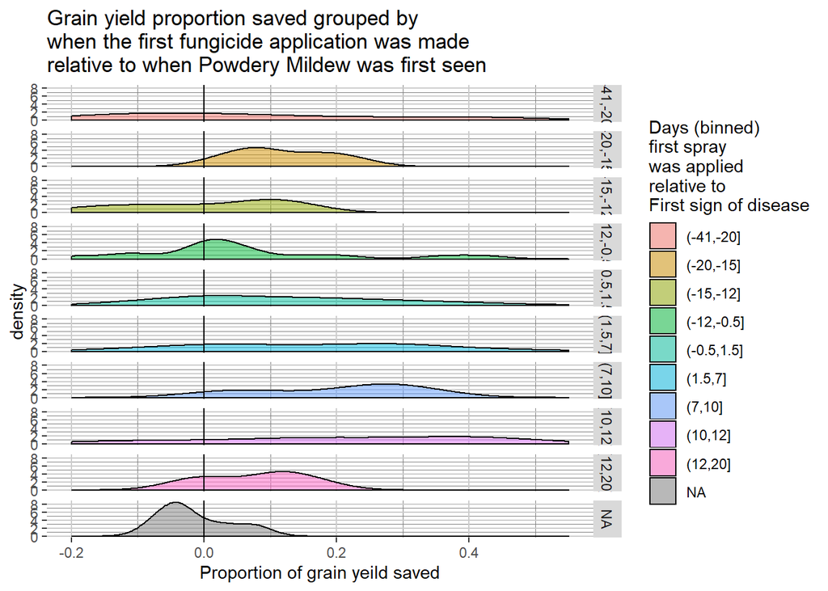

```r
ggplot(PM_MB_means1, aes(prop_YG))+
   geom_density(aes(fill = cut(PM_MB_means1$days_from_1st, c(-41,-20,-15,-12,-0.5,1.5,7,10,12,20))), alpha = 0.5)+
   geom_vline(aes(xintercept = 0), size =0.5)+
   facet_grid(cut(PM_MB_means1$days_from_1st, c(-41,-20,-15,-12,-0.5,1.5,7,10,12,20))~.)+
   #scale_fill_discrete(labels = c("15-7 days before","same day","one day after","8-9 days after","13-19 days after"))+
   labs(x = "Proportion of grain yeild saved",
   title = "Grain yield proportion saved grouped by\nwhen the first fungicide application was made\nrelative to when Powdery Mildew was first seen")+
   theme(panel.grid.major = element_line(colour = "grey80"),
         panel.grid.minor = element_line(colour = "grey50"),
         panel.background = element_rect(fill = NA))+
   guides(fill=guide_legend(title="Days (binned)\nfirst spray \nwas applied\nrelative to\nFirst sign of disease"))+
   scale_x_continuous(limits = c(-0.2,0.55))
```